# Pressures and the traits of fish species

We have seen that poor water quality brought slightly more fish species, favoring tolerant lowland cyprinids, while sensitive species (brown trout, brook lamprey) were lost (see D16). Such a turnover can hide a loss of functions if the species gained are functionally similar and those lost are specialists (Clavel et al. 2011; Mouillot et al. 2013).

Before measuring functional diversity, here we ask which (response) traits make a species sensitive to which pressure (Lavorel and Garnier 2002): each pressure (nutrients, oxygen, temperature, dams) is expected to filter species through its own traits (Poff 1997).

We (1) present the trait table and the pressures, (2) state the expected trait-pressure links, (3) test them with yearly averages of the pressures, and (4) ask whether summer conditions matter more than yearly averages.

## Setup

```r
library(renv)
renv::load()
```

```
- The project is out-of-sync -- use `renv::status()` for details.
```

```r
library(targets)
library(here)
tar_config_set(
  store = here::here("_targets")
)
library(ggplot2)
library(dplyr)
devtools::load_all()
nice_theme()
```

```r
# Colours shared by all figures.
colour_outcome <- c(`As expected` = "#2166AC", `Not credible` = "grey65", Opposite = "#B2182B")
colour_effect <- c(Positive = "#2166AC", `Not credible` = "grey70", Negative = "#B2182B")
pressure_label <- c(
  ammonium = "Ammonium", orthophosphate = "Orthophosphate",
  oxygen_saturation = "Oxygen saturation", temperature = "Water temperature",
  accumulation = "Dams to the sea", dam_below = "Dam just downstream",
  dam_above = "Dam just upstream"
)
trait_hypothesis_label <- c(
  intolerant = "Intolerant to poor water quality",
  omnivore = "Omnivore",
  lithophilic = "Spawns on gravel",
  oxygen_intolerant = "Intolerant to low oxygen",
  stenothermal = "Cold-water (stenothermal)",
  rheophilic = "Flowing water (rheophilic)",
  habitat_intolerant = "Intolerant to habitat degradation",
  diadromous = "Migrates to or from the sea",
  crossing = "Obstacle height crossed",
  non_native = "Non-native in France"
)
outcome <- function(mean, lower, upper, expected) {
  case_when(
    sign(lower) != sign(upper) ~ "Not credible",
    sign(mean) == expected ~ "As expected",
    .default = "Opposite"
  ) |>
    factor(names(colour_outcome))
}
```

## Data

### Fish traits

We use the fish trait table compiled for French rivers by Dézerald et al. [REF: Dézerald et al., year and doi to check] (`data/traits/dezerald_trait.csv`, trait descriptions in `data/traits/dezerald_metadata.xlsx`, their Table S2). It gathers traits from the French fish atlas [REF: Keith et al. 2011, book], FishBase [REF: Froese & Pauly, FishBase], the guilds of the European fish index EFI+ [REF: EFI+ Consortium 2009, report], freshwaterecology.info [REF: Schmidt-Kloiber & Hering 2015, doi:10.1016/j.ecolind.2015.02.007], morphological ratios measured on pictures [REF: Toussaint et al. 2016, doi:10.1038/srep22125] and the ability to cross obstacles of the ICE protocol [REF: Baudoin et al. 2014, Onema guide].

Preprocessing (targets `dezerald_trait` and `dezerald_metadata`): species names are validated against FishBase as ours, so that synonyms match (e.g. *Salmo trutta fario* is *Salmo trutta*, *Aspius aspius* is *Leuciscus aspius*); ordinal traits coded with a prefix (e.g. `ls3` for a longevity above 15 years) are converted to integers; taxonomy, conservation status and commercial interest are dropped.

```r
dezerald <- tar_read(dezerald_trait)
dezerald_metadata <- tar_read(dezerald_metadata)
river_species <- unique(tar_read(river_presence)$species_valid)
modelled_species <- tar_read(dam_presence_species)
trait_group <- c(
  mig = "Movement", food = "Diet", hab = "Habitat", life = "Life history",
  morp = "Size, growth and shape", tol = "Tolerance", rep = "Reproduction",
  ice = "Obstacle crossing (ICE)"
)
dezerald_river <- filter(dezerald, species %in% river_species)
dezerald_long <- dezerald_river |>
  select(-code, -abundance) |>
  mutate(across(-species, as.character)) |>
  tidyr::pivot_longer(-species, names_to = "trait") |>
  mutate(group = factor(trait_group[sub("\\..*", "", trait)], trait_group))
tibble(
  `Species in the table` = nrow(dezerald),
  `River species (ours)` = length(river_species),
  `River species covered` = nrow(dezerald_river),
  `Modelled species covered` = sum(modelled_species %in% dezerald$species)
) |>
  knitr::kable()
```

| Species in the table | River species (ours) | River species covered | Modelled species covered |
| --- | --- | --- | --- |
| 72 | 59 | 58 | 48 |

```r
dezerald_metadata |>
  filter(trait %in% dezerald_long$trait, !grepl("^food\\.(DET|PLANT|ANI)", trait)) |>
  summarise(
    name = first(name),
    categories = paste(category, collapse = ", "),
    .by = trait
  ) |>
  bind_rows(tibble(
    trait = "food.DET1 to food.ANI9", name = "Size classes of resource items (fuzzy)",
    categories = "affinity 0-5 to detritus, plants, animals of <1, 1-10, >10 mm"
  )) |>
  mutate(group = trait_group[sub("\\..*", "", trait)], .before = 1) |>
  arrange(factor(group, trait_group)) |>
  knitr::kable(col.names = c("Group", "Trait", "Description", "Categories"))
```

| Group | Trait | Description | Categories |
| --- | --- | --- | --- |
| Movement | mig.SWIMMODE | Swimming mode | subcarangiform, carangiform, labriform, anguilliform, diodontiform |
| Movement | mig.BODYSHAPE | Body forms and shapes | FLAT..DEEP, FUSI..STREAM, ELONG..CYL, EEL..LIKE |
| Movement | mig.MIGRATION | Migration | RESID..POTAD, LONG..LMA, POTAD, LONG..LMC, RESID |
| Movement | mig.DWC | Distance travelled with current when migrating | dwc2, dwc3, dwc4, dwc5 |
| Movement | mig.DAC | Distance travelled against current when migrating | dac2, dac3, dac4, dac5 |
| Diet | food.FFG | Functional feeding group | OMNI..INSV, INSV..OMNI, PLAN, INSV..PISC, INSV, PISC, OMNI, HERB, DETR |
| Diet | food.DET1 to food.ANI9 | Size classes of resource items (fuzzy) | affinity 0-5 to detritus, plants, animals of <1, 1-10, >10 mm |
| Habitat | hab.RHEO | Degree of rheophily | LIM, RH, EUR, EUR..RH, EUR..LIM |
| Habitat | hab.TROPH | Habitat trophic | B, WC |
| Habitat | hab.LIVING | Habitat living | BENT..PEL, PEL, DEM, DEM..BENT, BENT, DEM..PEL |
| Habitat | hab.RESP | Respiration mode | resp1, resp2 |
| Life history | life.LONG | Longetivity | ls1, ls2, ls3 |
| Life history | life.MAT | Maximum age of females at maturity | ma1, ma2, ma3, ma4, ma5 |
| Size, growth and shape | morp.LMIN | Minimum body size | 1, 2, 3, 4, 5 |
| Size, growth and shape | morp.LMEAN | Mean body size | 1, 2, 3, 4 |
| Size, growth and shape | morp.LMAX | Maximum body size | 1, 2, 3, 4, 5 |
| Size, growth and shape | morp.WMAX | Maximum body mass | 1, 2, 3, 4, 5, 6 |
| Size, growth and shape | morp.LARVLENGTH | Larval length | ll1, ll2, ll3 |
| Size, growth and shape | morp.GILLRAK | Maximum number of gill rakers | GRT1, GRT2 |
| Size, growth and shape | morp.MINK | Minimum parameter of the Von Bertalanffy Growth Function | 1, 2, 3, 4, 5 |
| Size, growth and shape | morp.MEANK | Mean parameter of the Von Bertalanffy Growth Function | 1, 2, 3, 4 |
| Size, growth and shape | morp.MAXK | Maximum parameter of the Von Bertalanffy Growth Function | 1, 2, 3, 4 |
| Size, growth and shape | morp.BLBD | Body elongation | 1, 2 |
| Size, growth and shape | morp.EHBD | Eye vertical position | 1, 2, 3, 4 |
| Size, growth and shape | morp.EHHD | Relative eye size | 1, 2, 3, 4 |
| Size, growth and shape | morp.MOBD | Oral gape position | 1, 2, 3, 4 |
| Size, growth and shape | morp.JLHD | Relative maxillary length | 1, 2, 3 |
| Size, growth and shape | morp.HDBD | Body lateral shape | 1, 2, 3, 4 |
| Size, growth and shape | morp.PFIBD | Pectoral fin vertical position | 1, 2, 3, 4 |
| Size, growth and shape | morp.PFLBD | Pectoral fin size | 1, 2, 3, 4 |
| Size, growth and shape | morp.CFDCPD | Caudal peduncle throttling | 1, 2, 3 |
| Tolerance | tol.GEN | General tolerance to water quality | TOL, IM, INTOL |
| Tolerance | tol.OXY | Tolerance to low oxygen concentration | O2TOL, O2IM, O2INTOL |
| Tolerance | tol.THERM | Thermal tolerance | EUTHER, STTHER |
| Tolerance | tol.HAB | Tolerance to habitat degradation | HTOL, HIM, HINTOL |
| Reproduction | rep.SPAWNMONTHSTART | Preferred first month of reproductive period | 1, 2, 3, 4, 5, 6, 7, 9, 11, 12 |
| Reproduction | rep.SPAWNMONTHEND | Preferred last month of reproductive period | 1, 2, 3, 4, 5, 6, 7, 8, 9, 12 |
| Reproduction | rep.REPPER | Reproductive period | st1, st2 |
| Reproduction | rep.CARE | Parental care | NOP, PROT |
| Reproduction | rep.REPMODE | Reproductive modes | PHLI, LITH, OTH, PHYT |
| Reproduction | rep.REPGUILD | Reproductive guilds | open..water..substratum..egg..scatterers, nesters, brood..hiders |
| Reproduction | rep.REPHAB | Habitat spawning preference | LIPAR, RHPAR, EUPAR |
| Reproduction | rep.SPAWNMODE | Reproductive behavior | SIN, FR |
| Reproduction | rep.REPCYCIND | Potential number of reproductive cycle per individual | rci1, rci2, rci3, rci4 |
| Reproduction | rep.INCUBPER | Length of incubation period | 1, 2, 3 |
| Reproduction | rep.REPPERLENGTH | Length of reproductive period | 2, 3, 4, 5 |
| Reproduction | rep.UPTHERMTOL | Upper thermal tolerance | inf..equa..20, 24, 25, 26, sup..equa..27 |
| Reproduction | rep.EGGDIAM | Egg diameter | 1, 2, 3, 4 |
| Reproduction | rep.ABSFEC | Absolute fecundity | 1, 2, 3, 4, 5, 6 |
| Reproduction | rep.RELFEC | Relative fecundity | 1, 2, 3 |
| Obstacle crossing (ICE) | ice.GROUP | ICE group number | 1..4, 3, 5..6, 7, 8, 9, 10, 11 |
| Obstacle crossing (ICE) | ice.CLASS0 | ICE class | 0..0.5m, 0.5..1m, 1..3m |
| Obstacle crossing (ICE) | ice.UMAX | Maximum speed | 1..2ms, 2..3ms, 3..4ms, 4..7ms |
| Obstacle crossing (ICE) | ice.HMIN | Minimum water height | 0..5cm, 5..15cm, 15..25cm |

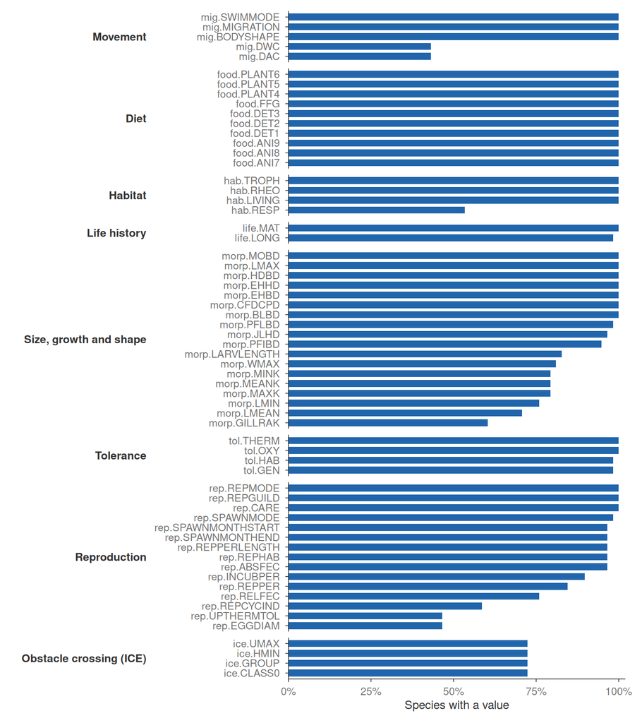

Share of our river species with a value for each trait.

```r
dezerald_long |>
  summarise(complete = mean(!is.na(value)), .by = c(group, trait)) |>
  mutate(trait = forcats::fct_reorder(trait, complete)) |>
  ggplot(aes(complete, trait)) +
  geom_col(fill = "#2166AC", width = 0.7) +
  facet_grid(group ~ ., scales = "free_y", space = "free_y", switch = "y") +
  scale_x_continuous(labels = scales::percent, expand = expansion(mult = c(0, 0.02))) +
  labs(x = "Species with a value", y = NULL) +
  theme(
    strip.text.y.left = element_text(angle = 0, hjust = 1),
    strip.placement = "outside",
    panel.grid.major.y = element_blank()
  )
```

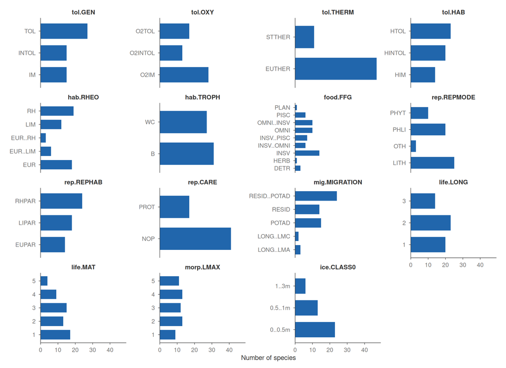

Number of species per category, for the traits used in the hypotheses below and a few others.

```r
key_trait <- c(
  "tol.GEN", "tol.OXY", "tol.THERM", "tol.HAB", "hab.RHEO", "hab.TROPH",
  "food.FFG", "rep.REPMODE", "rep.REPHAB", "rep.CARE", "mig.MIGRATION",
  "life.LONG", "life.MAT", "morp.LMAX", "ice.CLASS0"
)
dezerald_long |>
  filter(trait %in% key_trait, !is.na(value)) |>
  count(trait, value) |>
  mutate(trait = factor(trait, key_trait)) |>
  ggplot(aes(n, value)) +
  geom_col(fill = "#2166AC", width = 0.7) +
  facet_wrap(~trait, scales = "free_y", ncol = 4) +
  scale_x_continuous(expand = expansion(mult = c(0, 0.05))) +
  labs(x = "Number of species", y = NULL) +
  theme(panel.grid.major.y = element_blank())
```

**Results:**

### Pressures

Four water quality pressures, each expected to act on different traits (hypotheses below):

- **Ammonium**, as the nitrogen pressure. Nitrate is the main form of nitrogen in rivers, but it is little toxic to fish at the concentrations found there; the toxic forms are un-ionised ammonia (in equilibrium with ammonium) and nitrite [REF: Camargo & Alonso 2006, doi:10.1016/j.envint.2006.05.002]. Nitrate mostly traces the diffuse inputs of farmland (D15), while ammonium comes mainly from sewage and organic effluents [REF: Durand et al. 2011, European Nitrogen Assessment, ch. 7].
- **Orthophosphate**, the bioavailable form of phosphorus, which drives eutrophication.
- **Oxygen saturation**, low with organic pollution; used rather than the concentration, which mostly follows temperature.
- **Water temperature.**

Each pressure is predicted at the fish visits with the space-time model of the water quality index in D14 (station-year means of NAIADES, log10 for the nutrients; target `pressure_visit`), then centred and scaled.

Three dam metrics:

- **dams to the sea**: number of large dams and weirs between the site and the sea (accumulation, D12-D16), the access from the sea;
- **dam just downstream**: proximity of the nearest large dam downstream, the site may lie in or above its reservoir;
- **dam just upstream**: proximity of the nearest large dam upstream, which alters flow, temperature and sediment below it [REF: Poff et al. 1997, doi:10.2307/1313099].

Proximity is $-\log_{10}(d / 100\text{ km})$ with $d$ the distance along the river, set to 0 beyond 100 km: 1 at 10 km, 2 at 1 km.

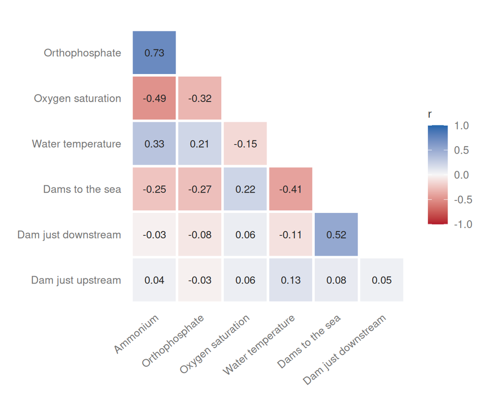

Correlation between the pressures at the fish visits.

```r
pressure_visit <- tar_read(pressure_visit_wide)
pressure_cor <- cor(select(pressure_visit, all_of(names(pressure_label))))
pressure_cor |>
  as.data.frame() |>
  tibble::rownames_to_column("x") |>
  tidyr::pivot_longer(-x, names_to = "y", values_to = "r") |>
  mutate(
    x = factor(pressure_label[x], pressure_label),
    y = factor(pressure_label[y], rev(pressure_label))
  ) |>
  filter(as.integer(x) < length(pressure_label) + 1 - as.integer(y)) |>
  ggplot(aes(x, y, fill = r)) +
  geom_tile(color = "white", linewidth = 1) +
  geom_text(aes(label = sprintf("%.2f", r)), size = 3.2, color = "grey15") +
  scale_fill_gradient2(low = "#B2182B", mid = "grey97", high = "#2166AC", limits = c(-1, 1), name = "r") +
  labs(x = NULL, y = NULL) +
  coord_equal() +
  theme(
    axis.text.x = element_text(angle = 40, hjust = 1),
    axis.line = element_blank(), axis.ticks = element_blank(),
    panel.grid.major.y = element_blank(), legend.position = "right"
  )
```

**Results:**

- The pressures are only moderately correlated; the strongest pair is ammonium and orthophosphate (0.73), which share the sewage source.
- The dam just downstream is correlated with the dams to the sea, since such a dam is also on the way to the sea.
- Variance inflation factors stay below 3, so all seven terms can be estimated together.
- Few visits are very close to a large dam (electrofishing is done in wadeable reaches, rarely in reservoirs).

## Hypotheses

For each pressure, we set in advance which traits should make a species more or less sensitive, and in which direction. “Expected effect” is the sign of the difference of response between species with and without the trait.

```r
hypothesis_rationale <- tibble::tribble(
  ~term, ~trait, ~rationale, ~reference,
  "ammonium", "intolerant", "Ammonia is toxic, sensitive species decline first", "Camargo & Alonso 2006, doi:10.1016/j.envint.2006.05.002",
  "ammonium", "omnivore", "Enrichment shifts the food base to algae, plankton and detritus", "Pont et al. 2006, doi:10.1111/j.1365-2664.2005.01126.x",
  "orthophosphate", "intolerant", "Eutrophication degrades habitat and oxygen", "Pont et al. 2006, doi:10.1111/j.1365-2664.2005.01126.x",
  "orthophosphate", "omnivore", "Enrichment shifts the food base to algae, plankton and detritus", "Pont et al. 2006, doi:10.1111/j.1365-2664.2005.01126.x",
  "orthophosphate", "lithophilic", "Phosphorus comes with fine sediment, which clogs spawning gravel", "Kemp et al. 2011, doi:10.1002/hyp.7940",
  "oxygen_saturation", "intolerant", "Sensitive species need well-oxygenated water", "Kramer 1987, doi:10.1007/BF00002597",
  "oxygen_saturation", "oxygen_intolerant", "Species with high oxygen demand", "Kramer 1987, doi:10.1007/BF00002597",
  "temperature", "stenothermal", "Cold-water species decline in warm rivers", "Buisson et al. 2008, doi:10.1111/j.1365-2486.2008.01657.x",
  "temperature", "rheophilic", "Flowing-water species live in cool upstream reaches", "Buisson et al. 2008, doi:10.1111/j.1365-2486.2008.01657.x",
  "accumulation", "diadromous", "Dams block the access from the sea", "Baudoin et al. 2014, Onema guide",
  "accumulation", "crossing", "Species crossing higher obstacles are less blocked", "Baudoin et al. 2014, Onema guide",
  "accumulation", "rheophilic", "Impoundments replace flowing water by still water", "Poff et al. 1997, doi:10.2307/1313099",
  "accumulation", "habitat_intolerant", "Dams degrade the habitat", "Poff et al. 1997, doi:10.2307/1313099",
  "dam_below", "rheophilic", "The reservoir turns flowing into still water", "Poff et al. 1997, doi:10.2307/1313099",
  "dam_below", "lithophilic", "Fine sediment settles in the reservoir", "Kemp et al. 2011, doi:10.1002/hyp.7940",
  "dam_below", "crossing", "Recolonisation from downstream needs to cross the dam", "Baudoin et al. 2014, Onema guide",
  "dam_above", "rheophilic", "Altered flow regime below the dam", "Poff et al. 1997, doi:10.2307/1313099",
  "dam_above", "lithophilic", "Altered sediment regime below the dam", "Poff et al. 1997, doi:10.2307/1313099",
  "accumulation", "non_native", "Reservoirs are stocked and suit introduced species", "Johnson et al. 2008, doi:10.1890/070156",
  "dam_below", "non_native", "Reservoirs are stocked and suit introduced species", "Johnson et al. 2008, doi:10.1890/070156",
  "dam_above", "non_native", "Introduced species spread downstream from reservoirs", "Johnson et al. 2008, doi:10.1890/070156"
)
hypothesis <- tar_read(trait_hypothesis) |>
  left_join(hypothesis_rationale, by = c("term", "trait"))
hypothesis |>
  transmute(
    Pressure = pressure_label[term], Trait = trait_hypothesis_label[trait],
    `Expected effect` = if_else(expected > 0, "+", "-"),
    Why = rationale, Reference = paste0("[REF: ", reference, "]")
  ) |>
  knitr::kable()
```

| Pressure | Trait | Expected effect | Why | Reference |
| --- | --- | --- | --- | --- |
| Ammonium | Intolerant to poor water quality | - | Ammonia is toxic, sensitive species decline first | [REF: Camargo & Alonso 2006, doi:10.1016/j.envint.2006.05.002] |
| Ammonium | Omnivore | + | Enrichment shifts the food base to algae, plankton and detritus | [REF: Pont et al. 2006, doi:10.1111/j.1365-2664.2005.01126.x] |
| Orthophosphate | Intolerant to poor water quality | - | Eutrophication degrades habitat and oxygen | [REF: Pont et al. 2006, doi:10.1111/j.1365-2664.2005.01126.x] |
| Orthophosphate | Omnivore | + | Enrichment shifts the food base to algae, plankton and detritus | [REF: Pont et al. 2006, doi:10.1111/j.1365-2664.2005.01126.x] |
| Orthophosphate | Spawns on gravel | - | Phosphorus comes with fine sediment, which clogs spawning gravel | [REF: Kemp et al. 2011, doi:10.1002/hyp.7940] |
| Oxygen saturation | Intolerant to poor water quality | + | Sensitive species need well-oxygenated water | [REF: Kramer 1987, doi:10.1007/BF00002597] |
| Oxygen saturation | Intolerant to low oxygen | + | Species with high oxygen demand | [REF: Kramer 1987, doi:10.1007/BF00002597] |
| Water temperature | Cold-water (stenothermal) | - | Cold-water species decline in warm rivers | [REF: Buisson et al. 2008, doi:10.1111/j.1365-2486.2008.01657.x] |
| Water temperature | Flowing water (rheophilic) | - | Flowing-water species live in cool upstream reaches | [REF: Buisson et al. 2008, doi:10.1111/j.1365-2486.2008.01657.x] |
| Dams to the sea | Migrates to or from the sea | - | Dams block the access from the sea | [REF: Baudoin et al. 2014, Onema guide] |
| Dams to the sea | Obstacle height crossed | + | Species crossing higher obstacles are less blocked | [REF: Baudoin et al. 2014, Onema guide] |
| Dams to the sea | Flowing water (rheophilic) | - | Impoundments replace flowing water by still water | [REF: Poff et al. 1997, doi:10.2307/1313099] |
| Dams to the sea | Intolerant to habitat degradation | - | Dams degrade the habitat | [REF: Poff et al. 1997, doi:10.2307/1313099] |
| Dam just downstream | Flowing water (rheophilic) | - | The reservoir turns flowing into still water | [REF: Poff et al. 1997, doi:10.2307/1313099] |
| Dam just downstream | Spawns on gravel | - | Fine sediment settles in the reservoir | [REF: Kemp et al. 2011, doi:10.1002/hyp.7940] |
| Dam just downstream | Obstacle height crossed | + | Recolonisation from downstream needs to cross the dam | [REF: Baudoin et al. 2014, Onema guide] |
| Dam just upstream | Flowing water (rheophilic) | - | Altered flow regime below the dam | [REF: Poff et al. 1997, doi:10.2307/1313099] |
| Dam just upstream | Spawns on gravel | - | Altered sediment regime below the dam | [REF: Poff et al. 1997, doi:10.2307/1313099] |
| Dams to the sea | Non-native in France | + | Reservoirs are stocked and suit introduced species | [REF: Johnson et al. 2008, doi:10.1890/070156] |
| Dam just downstream | Non-native in France | + | Reservoirs are stocked and suit introduced species | [REF: Johnson et al. 2008, doi:10.1890/070156] |
| Dam just upstream | Non-native in France | + | Introduced species spread downstream from reservoirs | [REF: Johnson et al. 2008, doi:10.1890/070156] |

Traits are binary (with or without), except the obstacle height crossed, an ICE class (1: below 0.5 m, 2: below 1 m, 3: below 3 m). The non-native status in France is taken from FishBase (target `native_status`).

## Yearly averages

### Responses of the species

The presence of each of the 48 species is modelled as in D16 (river position controls, sampling, site, year and spatial effects), with the three dam metrics and the four yearly pressures (target `species_pressure_model`).

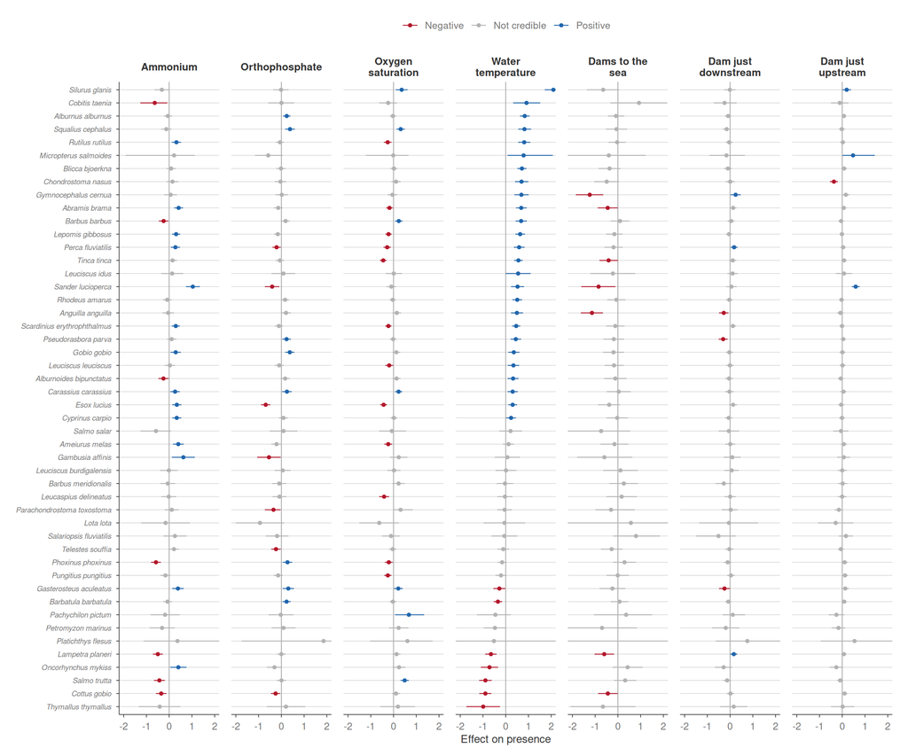

Effect of each pressure on the presence of each species (logit scale, per standard deviation of the pressure, 91% credible interval). Species are ordered by their response to temperature.

```r
pressure_response <- tar_read(species_pressure_response)
species_order <- pressure_response |>
  filter(term == "temperature") |>
  arrange(mean) |>
  pull(species)
pressure_response |>
  mutate(
    term = factor(pressure_label[term], pressure_label),
    species = factor(species, species_order),
    effect = case_when(
      sign(lower) != sign(upper) ~ "Not credible",
      mean > 0 ~ "Positive",
      .default = "Negative"
    )
  ) |>
  ggplot(aes(mean, species, color = effect)) +
  geom_vline(xintercept = 0, color = "grey60", linewidth = 0.3) +
  geom_linerange(aes(xmin = lower, xmax = upper), linewidth = 0.4) +
  geom_point(size = 1.2) +
  scale_color_manual(values = colour_effect) +
  coord_cartesian(xlim = c(-2, 2)) +
  facet_wrap(~term, nrow = 1, labeller = label_wrap_gen(12)) +
  labs(x = "Effect on presence", y = NULL, color = NULL) +
  theme(
    axis.text.y = element_text(face = "italic", size = 7),
    panel.spacing.x = unit(0.8, "lines"),
    legend.position = "top"
  )
```

**Results:**

### Traits explaining the responses

For each hypothesis, the effect of the pressure on each species is regressed on its trait, weighting each species by the precision of its effect, with a species random effect for the variation not explained by the trait (random-effects meta-regression; target `trait_response`). Testing the trait-pressure link across species avoids the inflated false positives of community trait means [REF: Peres-Neto et al. 2017, doi:10.1111/ecog.02302].

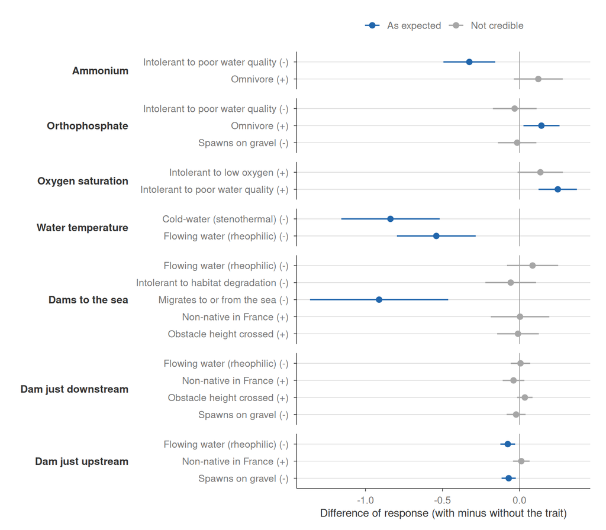

Difference of response to each pressure between species with and without the trait (logit per standard deviation of the pressure, per ICE class for the obstacle height; 91% credible interval). The sign expected a priori is in brackets.

```r
trait_response <- tar_read(trait_response) |>
  left_join(tar_read(trait_hypothesis), by = c("term", "trait")) |>
  mutate(
    pressure = factor(pressure_label[term], pressure_label),
    trait_label = paste0(trait_hypothesis_label[trait], " (", if_else(expected > 0, "+", "-"), ")"),
    outcome = outcome(mean, lower, upper, expected)
  )
trait_response |>
  ggplot(aes(mean, forcats::fct_rev(trait_label), color = outcome)) +
  geom_vline(xintercept = 0, color = "grey60", linewidth = 0.3) +
  geom_linerange(aes(xmin = lower, xmax = upper), linewidth = 0.6) +
  geom_point(size = 2.2) +
  scale_color_manual(values = colour_outcome) +
  facet_grid(pressure ~ ., scales = "free_y", space = "free_y", switch = "y") +
  labs(x = "Difference of response (with minus without the trait)", y = NULL, color = NULL) +
  theme(
    strip.text.y.left = element_text(angle = 0, hjust = 1, face = "bold"),
    strip.placement = "outside",
    panel.spacing.y = unit(0.6, "lines"),
    legend.position = "top"
  )
```

**Results:**

- Temperature has the strongest trait signature: cold-water and flowing-water species are much more sensitive to warm water.
- Ammonium: intolerant species are more sensitive.
- Oxygen: intolerant species are more favoured by well-oxygenated water.
- Phosphorus: only omnivores differ (favoured); the sensitivity of gravel spawners is not supported.
- Dams to the sea matter for migratory species only.
- Below a dam (dam just upstream), flowing-water species and gravel spawners are slightly less frequent; a dam just downstream acts through no trait.
- Non-native species do not respond to dams as a group.

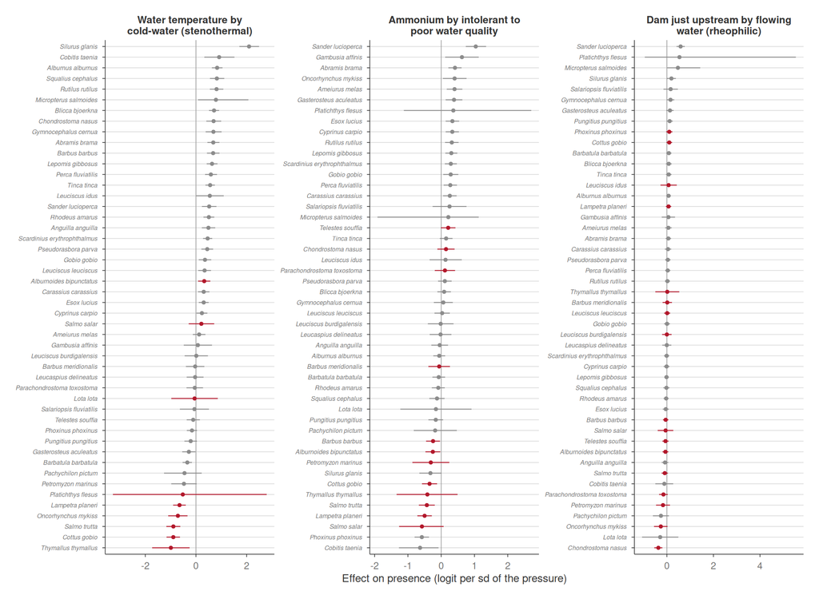

Effect of a pressure on the presence of each species (91% credible interval), with the trait (red) and without (grey).

```r
example <- tibble::tribble(
  ~term, ~trait,
  "temperature", "stenothermal",
  "ammonium", "intolerant",
  "dam_above", "rheophilic"
)
example_data <- purrr::pmap_dfr(example, \(term, trait) {
  pressure_response |>
    filter(.data$term == !!term) |>
    inner_join(select(tar_read(trait_predictor), species, value = all_of(trait)), by = "species") |>
    filter(!is.na(value)) |>
    mutate(
      panel = paste0(pressure_label[term], "\nby ", tolower(trait_hypothesis_label[trait])),
      group = if_else(value == 1, "With the trait", "Without")
    )
}) |>
  mutate(panel = factor(panel, unique(panel)))
example_data |>
  arrange(panel, mean) |>
  mutate(row = factor(paste(panel, species, sep = "___"), unique(paste(panel, species, sep = "___")))) |>
  ggplot(aes(mean, row, color = group)) +
  geom_vline(xintercept = 0, color = "grey60", linewidth = 0.3) +
  geom_linerange(aes(xmin = lower, xmax = upper), linewidth = 0.4) +
  geom_point(size = 1.2) +
  scale_color_manual(values = c(`With the trait` = "#B2182B", Without = "grey55"), guide = "none") +
  scale_y_discrete(labels = \(x) sub(".*___", "", x)) +
  facet_wrap(~panel, scales = "free", labeller = label_wrap_gen(30)) +
  labs(x = "Effect on presence (logit per sd of the pressure)", y = NULL) +
  theme(axis.text.y = element_text(face = "italic", size = 6))
```

**Results:**

*To discuss:*

- Each test uses at most 48 species, so only strong trait effects can be detected.
- Traits are correlated (intolerant species are often rheophilic and cold-water), so one trait may carry the effect of another.
- Nitrate was tried first instead of ammonium and showed no trait signature; the switch is supported by toxicity, but was made after seeing that result.
- The pressures are predicted, not measured, at most visits.

## Summer or yearly averages?

Longer averages (2, 3 and 5 years) were considered but not fitted: once predicted at the visits, they are almost identical to the yearly average (correlation ≥ 0.98), because the pressures differ much more between sites than between years. The summer averages differ more (correlation 0.85 to 0.97 with the yearly ones).

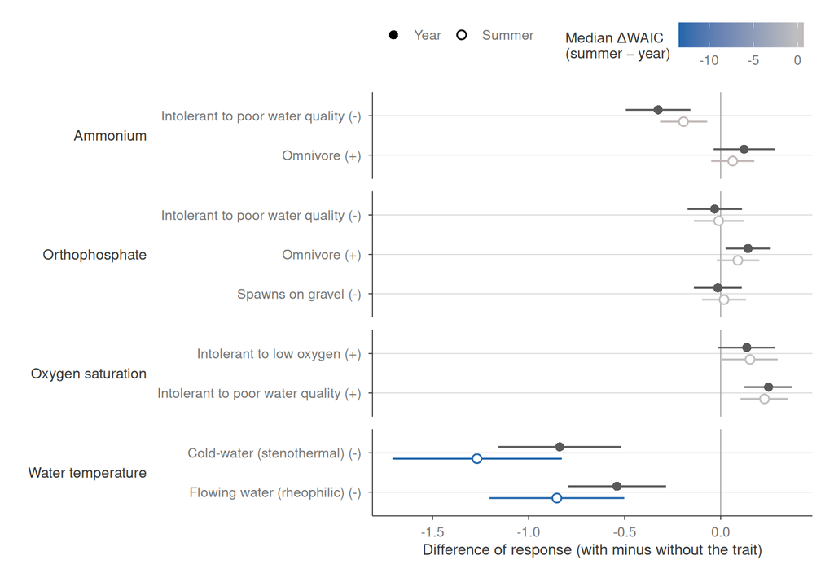

Difference of response between species with and without the trait (91% credible interval), with the pressure averaged over the year (grey) or over the summer (coloured by the median WAIC difference of the summer model with the yearly one over the common species; blue: summer fits better). The sign expected a priori is in brackets.

```r
occupancy <- tar_read(river_presence) |>
  filter(operation_id %in% pressure_visit$operation_id) |>
  distinct(species = species_valid, operation_id) |>
  count(species) |>
  mutate(occupancy = n / nrow(pressure_visit))
common_species <- filter(occupancy, occupancy >= 0.05)$species
timing_waic <- tar_read(timing_waic) |>
  filter(species %in% common_species) |>
  mutate(difference = waic - waic[duration == "1y"], .by = c(pressure, species)) |>
  filter(duration == "summer") |>
  summarise(
    waic = median(difference),
    better = sum(difference < -2),
    worse = sum(difference > 2),
    .by = pressure
  )
period_label <- c(`1y` = "Year", summer = "Summer")
tar_read(timing_trait_response) |>
  left_join(tar_read(trait_hypothesis), by = c("term", "trait")) |>
  left_join(select(timing_waic, term = pressure, waic), by = "term") |>
  mutate(
    pressure = factor(pressure_label[term], pressure_label),
    waic = if_else(duration == "summer", waic, NA),
    trait_label = paste0(trait_hypothesis_label[trait], " (", if_else(expected > 0, "+", "-"), ")"),
    period = factor(period_label[duration], period_label),
    outcome = outcome(mean, lower, upper, expected)
  ) |>
  ggplot(aes(mean, forcats::fct_rev(trait_label), color = waic, shape = period)) +
  geom_vline(xintercept = 0, color = "grey60", linewidth = 0.3) +
  geom_linerange(aes(xmin = lower, xmax = upper), linewidth = 0.6, position = position_dodge(width = -0.6)) +
  geom_point(size = 2.4, fill = "white", stroke = 0.8, position = position_dodge(width = -0.6)) +
  scale_color_gradient2(
    low = "#2166AC", mid = "grey75", high = "#B2182B", midpoint = 0, na.value = "grey35",
    name = "Median ΔWAIC\n(summer − year)"
  ) +
  scale_shape_manual(values = c(Year = 16, Summer = 21)) +
  facet_grid(pressure ~ ., scales = "free_y", space = "free_y", switch = "y") +
  labs(x = "Difference of response (with minus without the trait)", y = NULL, shape = NULL) +
  theme(
    strip.text.y.left = element_text(angle = 0, hjust = 1, face = "plain"),
    strip.placement = "outside",
    panel.spacing.y = unit(0.6, "lines"),
    legend.position = "top", legend.box = "horizontal"
  )
```

**Results:**

- Temperature: the summer average fits better for most common species and strengthens the trait signature of cold-water and flowing-water species.
- Ammonium, phosphorus and oxygen: the summer average fits no better than the yearly one and gives the same trait signatures (slightly weaker for ammonium and phosphorus).
- So the season matters for temperature only; the yearly averages are kept for the other pressures.

*To discuss:*

- The summer averages rest on 3 to 4 daytime samples per year, so the night oxygen minimum and the temperature peaks are missed.
- Choosing summer for some pressures and the year for others after this comparison would be fitting to the data unless justified in advance.

## Next steps

- **Functional diversity.** Measure the functional diversity of each community, e.g. functional richness and dispersion [REF: Villéger et al. 2008, doi:10.1890/07-1206.1] [REF: Laliberté & Legendre 2010, doi:10.1890/08-2244.1], against a null model shuffling species at fixed richness, to test whether poor water quality brings more species but less functional diversity.
- **Similarity between sites.** Test homogenisation directly: are sites with poor water quality more similar to each other than sites with clean water, at equal distance and river position? Splitting dissimilarity into turnover and nestedness separates the replacement of species from their simple loss or gain [REF: Baselga 2010, doi:10.1111/j.1466-8238.2009.00490.x].

## References

Clavel, Joanne, Romain Julliard, and Vincent Devictor. 2011. “Worldwide Decline of Specialist Species: Toward a Global Functional Homogenization?” *Frontiers in Ecology and the Environment* 9 (4): 222–28. https://doi.org/10.1890/080216.

Lavorel, S., and E. Garnier. 2002. “Predicting Changes in Community Composition and Ecosystem Functioning from Plant Traits: Revisiting the Holy Grail.” *Functional Ecology* 16 (5): 545–56. https://doi.org/10.1046/j.1365-2435.2002.00664.x.

Mouillot, David, David R. Bellwood, Christopher Baraloto, et al. 2013. “Rare Species Support Vulnerable Functions in High-Diversity Ecosystems.” *PLOS Biology* 11 (5): e1001569. https://doi.org/10.1371/journal.pbio.1001569.

Poff, N. LeRoy. 1997. “Landscape Filters and Species Traits: Towards Mechanistic Understanding and Prediction in Stream Ecology.” *Journal of the North American Benthological Society* 16 (2): 391–409. https://doi.org/10.2307/1468026.